# Spatial Predictions and Model Assesment

HES 505 Fall 2025: Session 29

Matt Williamson

## Reminders

- Draft Final Project due **Dec. 8**
- No Assignment 4
- Feedback on Code by EoW

# Objectives

By the end of today you should be able to:

- Articulate three different reasons for modeling and how they link to assessments of fit
- Describe and implement several test statistics for assessing model fit
- Describe and implement several assessments of classification
- Describe and implement resampling techniques to estimate predictive performance

# The 3 Faces of Models

## Best Model for What?

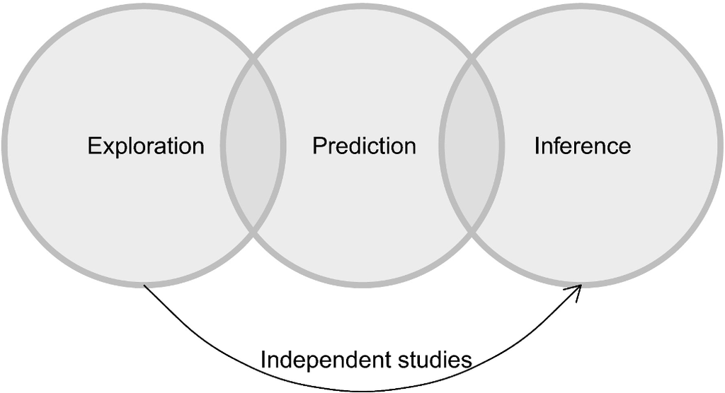

from Tradennick et al. 2021

- **Exploration:** describe patterns in the data and generate hypotheses
- **Inference:** evaluate the strength of evidence for some statement about the process
- **Prediction:** forecast outcomes at unsampled locations based on covariates

## The Importance of Model Fit

- The general regression context:

$$\begin{equation}
\hat{y} = \mathbf{X}\hat{\beta}
\end{equation}$$

- **Inference** is focused on robust estimates of $\hat{\beta}$ given the data we have
- **Prediction** is focused on accurate forecasts of $\hat{y}$ at locations where we have yet to collect the data

## Inference and Presence/Absence Data

- $\hat{\beta}$ is conditional on variables in the model **and** those not in the model

```r
nsamp <- 1000
df <- data.frame(x1 = rnorm(nsamp,0,1),
                 x2 = rnorm(nsamp,0,1),
                 x3 = rnorm(nsamp,0,1))

linpred <- 1 + 2*df$x1 -0.18*df$x2 -3.5*df$x3
y <- rbinom(nsamp, 1, plogis(linpred))
df <- cbind(df, y)

mod1 <- glm(y~x1 +x2, data=df, family="binomial")
mod2 <- glm(y~x1 +x2 + x3, data=df, family="binomial")
```

## Inference & Presence/Absence Data

```r
coef(mod1)
```

```
  (Intercept)            x1            x2
 0.4202437784  0.8989501472 -0.0007623703
```

```r
coef(mod2)
```

```
(Intercept)          x1          x2          x3
 0.92286788  1.86464860 -0.02121702 -3.10475414
```

```r
prd1 <- predict(mod1, df, "response")
dif1 <- plogis(linpred) - prd1
prd2 <- predict(mod2, df, "response")
dif2 <- plogis(linpred) - prd2
```

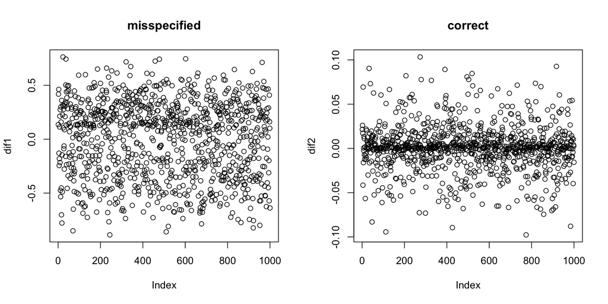

> Inferring coefficient effects requires that your model fit the data well

# Assessing Model Fit

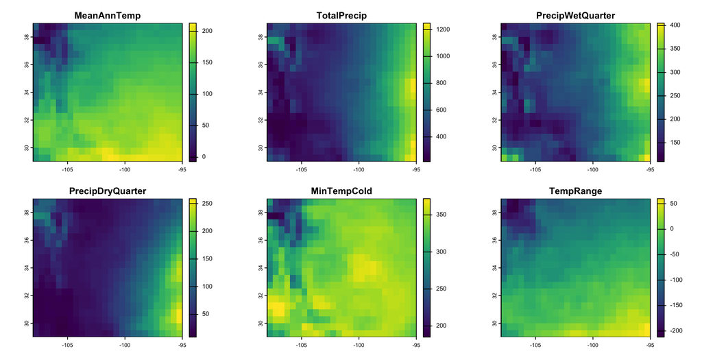

## Using Test Statistics

- $R^2$ for linear regression:

$$\begin{equation}
R^2 = 1- \frac{SS_{res}}{SS_{tot}}\\
SS_{res} = \sum_{i}(y_i- f_i)^2\\
SS_{tot} = \sum_{i}(y_i-\bar{y})^2
\end{equation}$$

- Perfect prediction ($f_i = y_i$); $SS_{res} = 0$; and $R^2 = 1$
- Null prediction (Intercept only) ($f_i = \bar{y}$); $SS_{res} = SS_{tot}$; and $R^2 = 0$
- No direct way of implementing for logistic regression

## Pseudo- $R^2$

$$\begin{equation}
R^2_L = \frac{D_{null} - D_{fitted}}{D_{null}}
\end{equation}$$

- Cohen’s Likelihood Ratio
- Deviance ($D$), the difference between the model and some hypothetical perfect model (lower is better)
- Challenge: Not monotonically related to $p$
- Challenge: How high is too high?

## Cohen’s Likelihood Ratio

```r
logistic.rich <- glm(y ~ MeanAnnTemp + PrecipWetQuarter +
                       PrecipDryQuarter,
                     family=binomial(link="logit"),
                     data=pts.df[,2:8])

with(logistic.rich,
     null.deviance - deviance)/with(logistic.rich,
                                    null.deviance)
```

```
[1] 0.4495966
```

## Pseudo- $R^2$

$$\begin{equation}
\begin{aligned}
R^2_{CS} &= 1 - \left( \frac{L_0}{L_M} \right)^{(2/n)}\\
&= 1 - \exp^{2(ln(L_0)-ln(L_M))/n}
\end{aligned}
\end{equation}$$

- Cox and Snell $R^2$
- Likelihood ($L$), the probability of observing the sample given an assumed distribution
- Challenge: Maximum value is less than 1 and changes with $n$
- Correction by Nagelkerke so that maximum is 1

## Cox and Snell $R^2$

```r
logistic.null <- glm(y ~ 1,
                     family=binomial(link="logit"),
                     data=pts.df[,2:8])

1 - exp(2*(logLik(logistic.null)[1] - logLik(logistic.rich)[1])/nobs(logistic.rich))
```

```
[1] 0.4308873
```

## Using Test Statistics

- Based on the data used in the model (i.e., not prediction)
- Likelihood Ratio behaves most similarly to $R^2$
- Cox and Snell (and Nagelkerke) increases with more presences
- Ongoing debate over which is “best”
- **Don’t defer to a single statistic**

# Assessing Predictive Ability

## Predictive Performance and Fit

- Predictive performance can be an estimate of fit
- Comparisons are often relative (better $\neq$ good)
- Theoretical and subsampling methods

## Theoretical Assessment of Predictive Performance

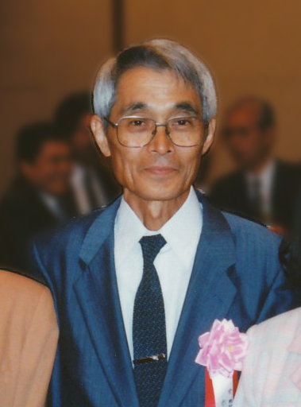

Hirotugu Akaike of AIC

- Information Criterion Methods
- Minimize the amount of information lost by using model to approximate true process
- Trade-off between fit and overfitting
- Can’t know the true process (so comparisons are relative)
  $$\begin{equation}
  AIC = -2ln(\hat{L}) +2k
  \end{equation}$$

## AIC Comparison

```r
logistic.null <- glm(y ~ 1,
                     family=binomial(link="logit"),
                     data=pts.df[,2:8])

logistic.rich <- glm(y ~ MeanAnnTemp + PrecipWetQuarter +
                       PrecipDryQuarter,
                     family=binomial(link="logit"),
                     data=pts.df[,2:8])

AIC(logistic.null, logistic.rich)
```

```
              df       AIC
logistic.null  1 127.37389
logistic.rich  4  77.00622
```

## Sub-sampling Methods

- Split data into *training* and *testing*
- Testing set needs to be large enough for results to be statistically meaningful
- Test set should be representative of the data as a whole
- Validation data used to tune parameters (not always)

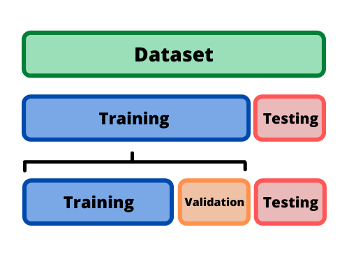

## Subsampling your data with `caret`

```r
pts.df$y <- as.factor(ifelse(pts.df$y == 1, "Yes", "No"))
library(caret)
Train <- createDataPartition(pts.df$y, p=0.6, list=FALSE)

training <- pts.df[ Train, ]
testing <- pts.df[ -Train, ]
```

## Misclassification

- Confusion matrices compare actual values to predictions
- True Positive (TN) - This is correctly classified as the class if interest / target.
- True Negative (TN) - This is correctly classified as not a class of interest / target.
- False Positive (FP) - This is wrongly classified as the class of interest / target.
- False Negative (FN) - This is wrongly classified as not a class of interest / target.

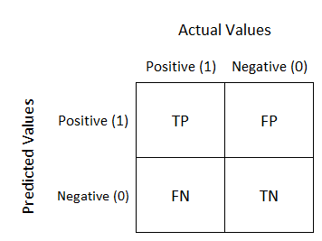

## Confusion Matrices in `R`

```r
train.log <- glm(y ~ .,
                 family="binomial",
                 data=training[,2:8])

predicted.log <- predict(train.log,
                         newdata=testing[,2:8],
                         type="response")

pred <- as.factor(
  ifelse(predicted.log > 0.5,
                         "Yes",
                         "No"))
```

```r
confusionMatrix(testing$y, pred)
```

```
Confusion Matrix and Statistics

          Reference
Prediction No Yes
       No  24   3
       Yes  2  10

               Accuracy : 0.8718
                 95% CI : (0.7257, 0.957)
    No Information Rate : 0.6667
    P-Value [Acc > NIR] : 0.003321

                  Kappa : 0.7059

 Mcnemar's Test P-Value : 1.000000

            Sensitivity : 0.9231
            Specificity : 0.7692
         Pos Pred Value : 0.8889
         Neg Pred Value : 0.8333
             Prevalence : 0.6667
         Detection Rate : 0.6154
   Detection Prevalence : 0.6923
      Balanced Accuracy : 0.8462

       'Positive' Class : No
```

## Confusion Matrices

$$\begin{equation}
\begin{aligned}
Accuracy &= \frac{TP + TN}{TP + TN + FP + FN}\\
Sensitivity &= \frac{TP}{TP + FN}\\
Specificity &= \frac{TN}{FP + TN}\\
Precision &= \frac{TP}{TP + FP}\\
Recall &= \frac{TP}{TP + FN}
\end{aligned}
\end{equation}$$

**Depends upon threshold!!**

## Confusion Matrices in `R`

```r
library(tree)
tree.model <- tree(y ~ . , training[,2:8])
predict.tree <- predict(tree.model,
                        newdata=testing[,2:8],
                        type="class")
```

```
Confusion Matrix and Statistics

          Reference
Prediction No Yes
       No  21   6
       Yes  3   9

               Accuracy : 0.7692
                 95% CI : (0.6067, 0.8887)
    No Information Rate : 0.6154
    P-Value [Acc > NIR] : 0.03202

                  Kappa : 0.4935

 Mcnemar's Test P-Value : 0.50499

            Sensitivity : 0.8750
            Specificity : 0.6000
         Pos Pred Value : 0.7778
         Neg Pred Value : 0.7500
             Prevalence : 0.6154
         Detection Rate : 0.5385
   Detection Prevalence : 0.6923
      Balanced Accuracy : 0.7375

       'Positive' Class : No
```

## Confusion Matrices in `R`

```r
library(randomForest)
class.model <- y ~ .
rf <- randomForest(class.model,
                   data=training[,2:8])
predict.rf <- predict(rf,
                      newdata=testing[,2:8],
                      type="class")
```

```
Confusion Matrix and Statistics

          Reference
Prediction No Yes
       No  24   3
       Yes  4   8

               Accuracy : 0.8205
                 95% CI : (0.6647, 0.9246)
    No Information Rate : 0.7179
    P-Value [Acc > NIR] : 0.1031

                  Kappa : 0.5687

 Mcnemar's Test P-Value : 1.0000

            Sensitivity : 0.8571
            Specificity : 0.7273
         Pos Pred Value : 0.8889
         Neg Pred Value : 0.6667
             Prevalence : 0.7179
         Detection Rate : 0.6154
   Detection Prevalence : 0.6923
      Balanced Accuracy : 0.7922

       'Positive' Class : No
```

## Threshold-Free Methods

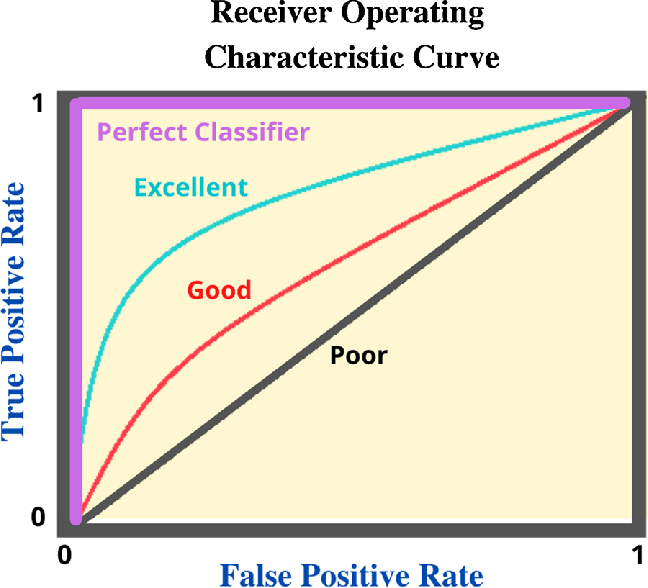

- Receiver Operating Characteristic Curves
- Illustrates discrimination of binary classifier as the threshold is varied
- Area Under the Curve (AUC) provides an estimate of classification ability

## Criticisms of ROC/AUC

- Treats false positives and false negatives equally
- Undervalues models that predict across smaller geographies
- Focus on *discrimination* and not *calibration*
- New methods for presence-only data

## ROC in R (using `pROC`)

- Generate predictions (note the difference for tree and rf)

```r
library(pROC)
train.log <- glm(y ~ .,
                 family="binomial",
                 data=training[,2:8])

predicted.log <- predict(train.log,
                         newdata=testing[,2:8],
                         type="response")

predict.tree <- predict(tree.model,
                        newdata=testing[,2:8],
                        type="vector")[,2]

predict.rf <- predict(rf,
                      newdata=testing[,2:8],
                      type="prob")[,2]
```

## ROC in R (using `pROC`)

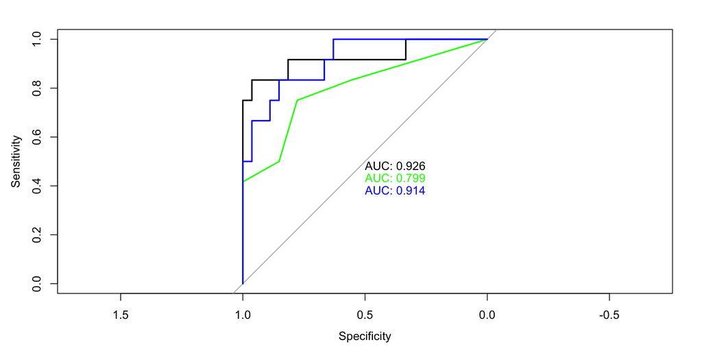

## Cross-validation

- Often want to make sure that fit/accuracy not a function of partition choice
- Cross-validation allows resampling of data (multiple times)
- K-fold - Data are split into K datasets of ~ equal size, model fit to $(K-1)(\frac{n}{K})$ observations to predict heldout set
- Leave One Out (LOO) - Model fit to n-1 observations to predict the held out observation

## Crossvalidation in `R` using `caret`

```r
fitControl <- trainControl(method = "repeatedcv",
                           number = 10,
                           repeats = 10,
                           classProbs = TRUE,
                           summaryFunction = twoClassSummary)

log.model <- train(y ~., data = pts.df[,2:8],
               method = "glm",
               trControl = fitControl)
pred.log <- predict(log.model,
                    newdata = testing[,2:8],
                    type="prob")[,2]

tree.model <- train(y ~., data = pts.df[,2:8],
               method = "rpart",
               trControl = fitControl)

pred.tree <- predict(tree.model,
                     newdata=testing[,2:8],
                     type="prob")[,2]

rf.model <- train(y ~., data = pts.df[,2:8],
               method = "rf",
               trControl = fitControl)
pred.rf <- predict(rf.model,
                   newdata=testing[,2:8],
                   type="prob")[,2]
```

## Crossvalidation in `R` using `caret`

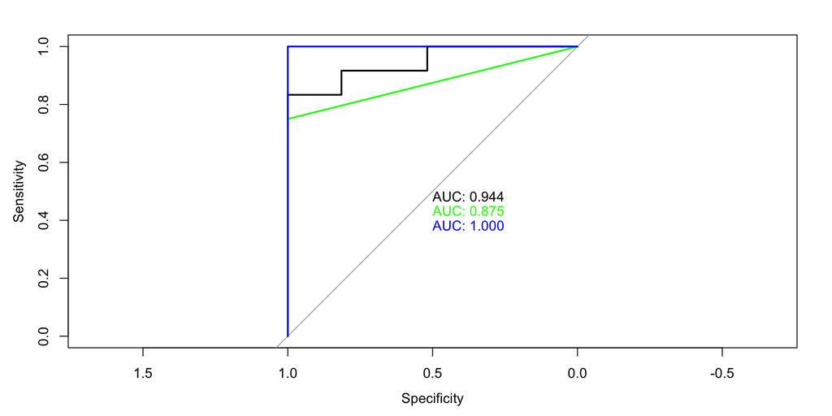

## Crossvalidation in `R` using `caret`

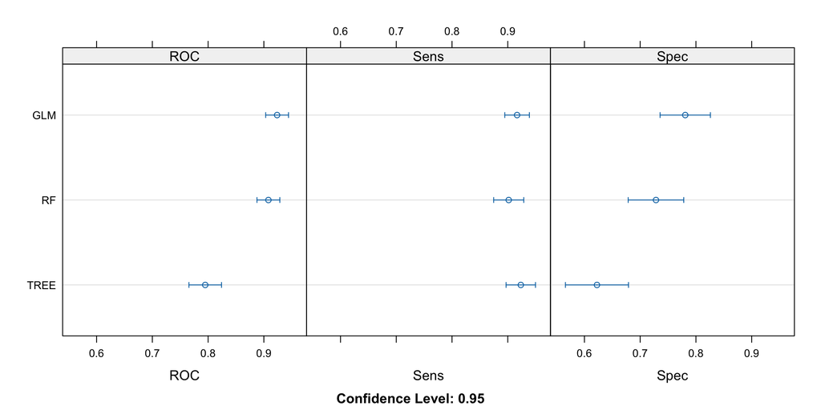

## Spatial predictions

```r
best.rf <- rf.model$finalModel
best.glm <- log.model$finalModel

rf.spatial <- terra::predict(pred.stack.scl,
                             best.rf,
                             type="prob")


glm.spatial <- terra::predict(pred.stack.scl,
                              best.glm,
                              type="response" )
```

## Spatial predictions

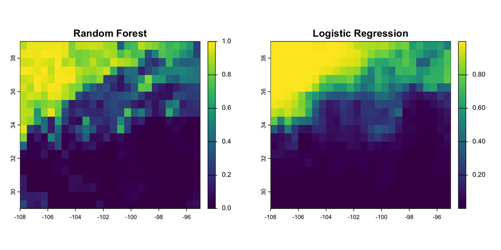